# Notes: FlipFlop NPIs

# Intro

- monotonicity and NPIs

> #Petr měl sebemenší tušení, kde je Marie.

> Petr neměl sebemenší tušení, kde je Marie.

> Petr měl kolo.

> $\leftarrow$ Petr měl červené kolo. … $\uparrow$

> Petr neměl kolo.

> $\rightarrow$ Petr neměl červené kolo. … $\downarrow$

# Inferences and monotonocity

- people make inferences like the following:

> More than half of the tourist have the flu.

> $\rightarrow$ More than half of the tourists are sick.

> All tourists have the flu.

> $\rightarrow$ All tourists are sick.
- but only the second inference is valid in FOL
- the complexity isn’t psychologically detectable
- Geurts and Slik (2005): monotonicity helps, it allows shallow and quick inferences: upward, downward, etc.
- from this perspective: NPIs help to make inferences (clues of the downward monotonicity of the sentence)
- Geurts and Slik (2005): not about NPIs but about some general rules of inference
- one of their patterns:

> $\uparrow$Det$_A$ $\uparrow$Det$_B$ < $\downarrow$Det$_A$ $\downarrow$Det$_B$ < {$\uparrow$Det$_A$ $\downarrow$Det$_B$, $\downarrow$Det$_A$ $\uparrow$Det$_B$}
- Geurts and Slik (2005): experiment on syllogisms

> Det$_A$ A played against Det$_B$ B. (major promise)

> All B were C. (minor promise)

> Det$_A$ A played against Det$_B$ C. (conclusion)
- Det$_A$: ‘every’, ‘most’, ‘some’, ‘at least 3’, ‘at most 3’, ‘no’
- Det$_B$: ‘more than 2’ or ‘fewer than 2’.
- A, B, C: substantives like ‘forester’, ‘nurse’, ’socialist
- Czech examples of the hierarchy:

> Všichni lesníci hráli proti více než dvěma socialistům.

> Všichni socialisté byli traktoristé.

> Všichni lesníci hrálí proti více než dvěma traktoristům.
- harder:

> Žádní traktoristé nehráli proti méně než dvěma socialistům.

> Všichni socialisté byli učitelé.

> Žádní traktoristé nehráli proti méně než dvěma učitelům.
- the hardest:

> Nanejvýš dva lesníci hráli proti více než dvěma socialistům.

> Všichni socialisté byli učitelé.

> Nanejvýš dva lesníci hráli proti více než dvěma učitelům.
- the results:

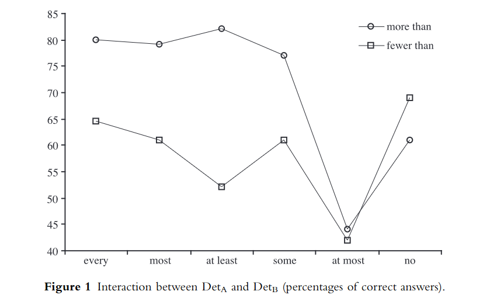

Graph

- questions: the prediction seems to be that any kind of monotonicity operator should behave similarly:
> 1. the easiest: Někteří lidé vyhráli jednu hru.
> 2. harder: Méně než polovina lidí nevyhrála žádnou hru.
> 3. the hardest: Více než polovina lidí nevyhrála žádnou hru.
- another question: NPIs and locality vs. inferences and locality
  - is there a difference between:
> 1. Pochybuju, že si nekoupil auto.
> 2. Nepochybuju, že si koupil auto.
- but checking the intuitions via sylllogisms is cool
- one way to do it (UE):

> Petr nepochybuje, že si Marie koupila auto.

> Všechna auta jsou dopravní prostředky.

> Petr nepochybuje, že si Marie koupila dopravní prostředek.
- DE:

> Petr nepochybuje, že si Marie koupila auto.

> Všechna auta na benzín jsou auta.

> Petr nepochybuje, že si Marie koupila auto na benzín.

## Series of experiments

### Szabolcsi, Bott, and McElree (2008)

- first negative results
- example item from the main experiment:

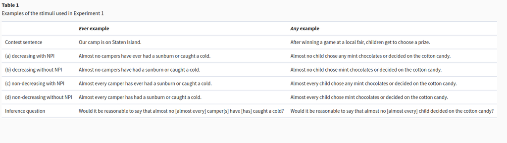

Szabolcsi

- DE: $p \rightarrow (p \vee q)$
- the expectation was that the NPI would facilitate the DE inference
- generally: DE and UE operators, NPI or not below them
- the results:

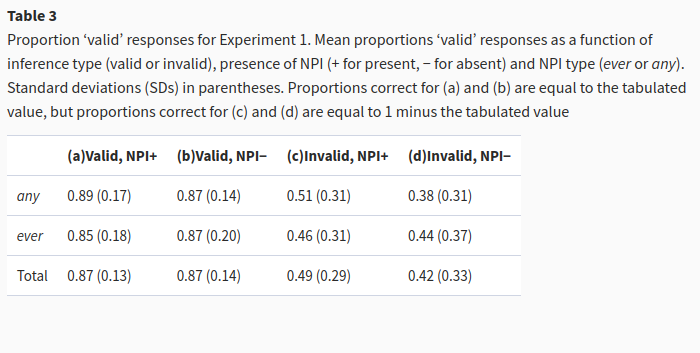

Szabolcsi2

- $\neg((p \vee q) \rightarrow \neg p)$ is valid
- the material is slightly questionable but the experiment is well designed
- the authors comment on the results as follows: “Given the existing evidence on NPI licensing, it seems almost like a foregone conclusion that the processor should recognize the relationship between monotonicity and NPI licensing. Indeed, when we started this project, our intention was to investigate how this recognition occurred, rather than whether it occurred. As is often the case, however, expectations did not match results and we were unable to find evidence for the recognition.”

### Chemla, Homer, and Rothschild (2011)

- batch of experiments looking at monotonicity, scalar implicatures and NPIs
- the NPI and monotonicity part are the following:

> no-NPI: Chaque alien qui a de l’intéret pour la littérature est rouge.

> Every alien who takes an interest in literature is red.

> NPI: Chaque alien qui a le moindre intéret pour la littérature est rouge.

> Every alien who takes any interest in literature is red.
- French NPI *le moindre* (literally ‘the least’) – very close to Czech *sebemenší*
- monotonicity part:

> Set: Chaque alien a fait de la danse.

> Every Alien practiced dance.

> Subset: Chaque alien a fait de la danse classique.

> Every Alien practiced classical dance.
- quantifiers varied (downward, upward, non-monotonic): *no, some, every, less than 12, at most 12, exactly 12, only 12*
- the results: the inferences a particular person considers valid in a given linguistic environment predict how acceptable they would find an NPI in that same environment
- first positive result
- the method: correlation between the (by speaker) acceptance of NPI and her monotonicity judgments
- but the correlation worked only in case both PPI and NPI results were aggregated

## Denić et al. (2021)

- again experiment on NPIs and reasoning
- they start with an assumption: in cases where reasoning is easy, adding NPIs doesn’t make a difference (as in Szabolcsi, Bott, and McElree (2008))
- first environment: non-monotonic quantifiers (the crucial condition)

> Exactly 12 aliens saw (some/any) birds.

> Exactly 12 aliens saw doves.
- the effect is very small and significant only in experiment 2 (both premise and conclusion contani PIs)
- but in UE reasoning, presence of NPIs makes a difference
- examples like:

> Exactly 12 aliens saw any doves.

> Exactly 12 aliens saw any birds.
- presence of NPI makes the inference less acceptable: “with inferences without PI and with a PPI receiving similar directional ratings (59.2%, SD = 14.9 and 60.1%, SD = 14.1, respectively), and the presence of NPIs leading to lower ratings (54.7%, SD = 12.5)”
- second environment: double DE
- every and no, subset, superset

> Every alien who did not see (some/any) doves is hairy.

> Every alien who did not see birds is hairy.

> No alien spent a year without seeing (some/any) doves.

> No alien spent a year without seeing birds.
- “no effect of the presence of NPIs on the global monotonicity inference was found, but interestingly, an effect of the PPI was found”
- in experiment 4 they found some effect even with NPIs

## Interim summary

- the effects of NPIs/PPIs are either non-detectable or very small

## Locality and NPIs: Mayer, Wurmbrand, and Sprouse (2019)

- experimental evidence for the flip-flop effect:

> I doubt that John bought any books.

> ?I don’t doubt that John bought any books.

> I doubt that John didn’t buy any books.

## Experimental items

- the correlation is probably more clear
- the inferences:
- first, one DE:

> Pochybuju o tom, že by Karel napsal román.

> -> Pochybuju o tom, že by Karel napsal psychologický román.

> -/-> Pochybuju o tom, že by Karel napsal knihu.
- second, two DE:

> Nepochybuju o tom, že Karel napsal román.

> -> Nepochybuju o tom, že Karel napsal knihu.

> -/-> Nepochybuju o tom, že Karel napsal psychologický román.
- and then acceptability of NPIs in the same contexts:

> Pochybuju, že by měl sebemenší šanci ten svůj návrh prosadit.

> Nepochybuju, že by měl sebemenší šanci ten svůj návrh prosadit.
- playing with locality would go beyond Denić et al. (2021) (both UE in monotonicity but only the second should license NPIs):

> Nepochybuju, že by měl sebemenší šanci ten svůj návrh prosadit.

> Pochybuju, že by neměl sebemenší šanci ten svůj návrh prosadit.
- but in fact (if successful) it would show that NPIs licensing and monotonicity inferences are two different things

## The scope theory?

- what if Szabolcsi, Bott, and McElree (2008) was right (also the magnitude of effects in Denić et al. (2021) and others is nearly anecdotal)
- DE doesn’t work for non-monotonic quantifiers anyway
- (**alexandropoulou2020there?**): non-montonic quantifiers license NPIs:

> Exactly two of the boxes contain anything.
- Czech example from Sketch engine:

> jen minimum automobilek se rozhodne zamlčet sebemenší problém
- very promissing theory: Barker (2018)
- NPIs mark narrow scope in case it is logically stronger (or at least not weaker) than the wide scope

DE environment in the scope theory:

> Petr tam nenašel sebemenší zmínku o ztracené knize.

> $\neg \exists x[P(x) \wedge Q(x)] \rightarrow \exists x[P(x) \wedge \neg Q(x)]$ (for non-empty domain)

> $\exists x[P(x) \wedge \neg Q(x)] \not\rightarrow \neg \exists x[P(x) \wedge Q(x)]$

UE:

> #Každý badatel tam našel sebemenší zmínku o ztracené knize.

> $\forall x[P(x) \rightarrow \exists y[Q(x) \wedge R(x,y)]] \not\rightarrow \exists y[Q(y) \wedge \forall x(P(x) \rightarrow R(x,y))]$

> $\exists y[Q(y) \wedge \forall x(P(x) \rightarrow R(x,y))] \rightarrow \forall x[P(x) \rightarrow \exists y[Q(x) \wedge R(x,y)]]$
- for non-monotonic, there is at least no entailment in either direction

## First idea of conditions: the conjunction

- *ani* vs. *nebo* in scope of negated propositional attitude verbs (Neg-Raising or DE: *chtít* vs. *doufat*)

> Nechci, aby pršelo ani/nebo sněžilo.

> $\mathrm{want}[\neg(p \vee q)]/[\neg p \vee \neg q]$
- correlate with

> Nechci, aby Petr ani/nebo Marie přišli.

## In the nominal domain

- Barker (2018): FCI reading of *any* (‘if you’re in the habit of sleeping with just anyone’) is the scope of *any* under silent generic operator
- (NPI reading: ‘If there is anyone that you sleep with’)

> If you sleep with (just) anyone, you should use a condom.
- both NPI and FCI readings are licensed if the narrow scope isn’t weaker than the wide scope
- *-koliv* FCIs scope narrow: Strachoňová (2017 [cit. 2024-02-19])
- couple of environments (non-formal experiment from (**strachonova2017scope?**)):
1. antecedent implikace
- široký skopus: Karel chystá oslavu narozenin. Mezi pozvanými jsou i jeho kolegyně z práce, Katka a Milena. Ty se nemají vůbec rády, a když se někde potkají, obě se urazí.
- úzký skopus: úzký skopus: Petr pořádá oslavu narozenin a pozval Katku. Katka si myslí, že to bude soukromé rande a nikdo další se tam neobjeví. Až zjistí, jak to je, bude určitě naštvaná.

> Katka se urazí, jestli kdokoliv přijde na tu oslavu.
2. modální sloveso *moci*
3. univerzální kvantifikátor (*všechen*):
- široký skopus: Petr s Marií jsou na výstavě šperků z drahých kamenů. Mají tu spoustu náušnic a náhrdelníků, ale jenom jeden prsten, který je ale podle návštěvnic výstavy nejkrásnější ze věch exponátů.
- úzký skopus: Petr s Marií jsou na výstavě šperků z drahých kamenů. Mají tu spoustu náušnic, náhrdelníků a prstenů. Mezi návštěvnicemi výstavy panuje zvláštní shoda v tom, že náhrdelníky a náušnice se moc nepovedly, ale prsteny jsou krásné

> Všem ženám na výstavě se líbil jakýkoliv prsten.
4. komparativ
5. neprůhledné sloveso *chtít*
6. downward entailing operátor (*bez*)
7. negované existenční modální sloveso (*ne-moci*)
- experiment: 2 varianty
- 20 subjektů, 10 na přeskáčku široký-úzký, 10 obrácně (úzký-široký)
- ne plný latin-square, ale rozhodně použitelné
- výsledky (konzervativně: 1 plné přijetí nebo odmítnutí širokého skopu, 0 odmítnutí úzkého skopu nebo nezaznamenáno: odmítnutí vyjádření)
- 1: úzký skopus

```r
# sequence of 18 true values in the boolean vector

implikace <- c(rep(TRUE, 18), rep(FALSE, 2))
moci <- c(rep(TRUE, 20))
universal <- c(rep(TRUE, 14), rep(FALSE, 6))
komparativ <- c(rep(TRUE, 19), rep(FALSE, 1))
bez <- c(rep(TRUE, 19), rep(FALSE, 1))
chtit <- c(rep(TRUE, 20))
modalni <- c(rep(TRUE, 16), rep(FALSE, 4))

# merge into one vector
all <- c(implikace, moci, universal, komparativ, bez, chtit, modalni)
summary(all)
```

```
   Mode   FALSE    TRUE
logical      14     126
```

```r
14+126
```

```
[1] 140
```

```r
# very simplified assumptions: half, half scope

all_table <- matrix (c(70, 70, 14, 126), nrow = 2, byrow = TRUE)

library(BayesFactor)
bf = contingencyTableBF(all_table, sampleType = "indepMulti", fixedMargin = "cols")
bf
```

```
Bayes factor analysis
--------------
[1] Non-indep. (a=1) : 273715845933 ±0%

Against denominator:
  Null, independence, a = 1
---
Bayes factor type: BFcontingencyTable, independent multinomial
```

- but for universal:

```r
universal_table <- matrix (c(10, 10, 6, 14), nrow = 2, byrow = TRUE)

bf = contingencyTableBF(universal_table, sampleType = "indepMulti", fixedMargin = "cols")
bf
```

```
Bayes factor analysis
--------------
[1] Non-indep. (a=1) : 0.8467056 ±0%

Against denominator:
  Null, independence, a = 1
---
Bayes factor type: BFcontingencyTable, independent multinomial
```

### Natural example

- from Sketch Engine

> Ale jen polovina z toho měla vůbec jakoukoli souvislost s covidem.

## Ideas for the experiment

- non-monotonic licensing of Czech FCIs
- check both scope and monotononicity
- the magnitude of the effect then resolves the question: scope of monotonicity

> Jen polovina studentů projevila jakoukoliv znalost geometrie.
> 1. široký skopus: Všichni z té lepší poloviny nakreslili pravoúhlý trojúhelník, ale jinak neuměli nic.
> 2. úzký skopus: V té lepší polovině někteří nakreslili pravoúhlý trojúhelník, jiní spočítali Pythagorovu větu, pár jich dokonce vědělo, co je to euklidovská vzdálenost.

### Double negation

- also possible but probably harder to find the right environment
- since in the localist theories one DE environment is enough

## References

Barker, Chris. 2018. “Negative Polarity as Scope Marking.” *Linguistics and Philosophy* 41 (5): 483–510.

Chemla, Emmanuel, Vincent Homer, and Daniel Rothschild. 2011. “Modularity and Intuitions in Formal Semantics: The Case of Polarity Items.” *Linguistics and Philosophy* 34: 537–70.

Denić, Milica, Vincent Homer, Daniel Rothschild, and Emmanuel Chemla. 2021. “The Influence of Polarity Items on Inferential Judgments.” *Cognition* 215: 104791.

Geurts, Bart, and Frans van der Slik. 2005. “Monotonicity and Processing Load.” *Journal of Semantics* 22 (1): 97–117. https://doi.org/10.1093/jos/ffh018.

Mayer, Erika, Susanne Wurmbrand, and Jon Sprouse. 2019. “An Experimental Investigation of NPI Licensing Under DE Flip-Flop.” In *Roceedings of the North East Linguistics Society 48*. University of Iceland.

Strachoňová, Hana. 2017 [cit. 2024-02-19]. “Česká Free Choice Indefinita [Online].” Disertační práce, Masarykova univerzita, Filozofická fakulta, Brno. https://is.muni.cz/th/gmdxp/.

Szabolcsi, Anna, Lewis Bott, and Brian McElree. 2008. “The Effect of Negative Polarity Items on Inference Verification.” *Journal of Semantics* 25 (4): 411–50.